# Distribuciones Continuas

Las distribuciones que hemos estudiado hasta ahora están definidas sobre variables *discretas*: la Binomial, Geométrica, Binomial Negativa, e Hipergeométrica, explícitamente modelan *conteos* de ciertos eventos, y aunque la distribución Bernoulli sólo está definida sobre éxito/fracaso, puede interpretarse como el *número de éxitos posibles* en un ensayo binario.

Las variables que modelan conteos son el ejemplo clásico de variables discretas, y ayudan a hacer explícita la característica principal de este tipo de variables: *en una variable discreta es posible identificar algún intervalo en el dominio de la variable tal que **ya no es posible** que la variable tome un valor dentro de ese intervalo*. En el caso de las variables para conteos, por ejemplo, es imposible que las variables en cuestión tomen un valor, digamos, entre $23.2$ y $23.8$. La idea intuitiva es que al hacer "zoom" en ciertas regiones de la variable eventualmente encontraremos un intervalo que no contiene ningún valor válido de una variable **discreta**:

[figure not shown]

Es importante resaltar que esta característica no impide que las variables discretas puedan tener un soporte de longitud infinita: una variable Binomial Negativa, por ejemplo, puede tomar cualquier valor **entero** desde $0$ hasta $\infty$, y al mismo tiempo siempre es posible identificar cierto intervalo, incluso en regiones de valores elevados, en el que la variable no tiene ningún valor posible (p.ej., de $281456.1$ a $281456.3$).

Las variables **continuas**, en cambio, pueden tomar cualquier valor en su dominio. O, en otras palabras, en este tipo de variables **no** es posible identificar ningún intervalo dentro de su dominio en el que la variable no tenga valores válidos o posibles. Siguiendo la idea del zoom, no importa qué tan fino hagamos el aumento y pequeño el intervalo, éste ¡siempre contendrá un número infinito de valores posibles de la variable!

[figure not shown]

Esta característica vuelve a las variables continuas entidades un tanto "extrañas" en Teoría de Probabilidad, o al menos no tan intuitivas como las variables discretas. Quizá la diferencia más importante entre ambos tipos de variables es que para una variable continua $Z$ definida en los *números reales* ($\mathbb{R}$):

$$P(Z=z)=0,\ \forall z \in \mathbb{R},$$

es decir, es *"imposible"* que la variable tome cualquiera de sus posibles valores. Sin embargo, y al mismo tiempo, existe una probabilidad positiva de que la variable tome un valor *dentro de cierto intervalo* $[a,b]$ en su dominio:

$$P(a\leq Z\leq b)\geq0$$

Para calcular los valores de probabilidad correspondiente se utiliza cierta función definida sobre la variable, referida como *función de **densidad** de probabilidad*. Esta función $f(z)$ representa la incertidumbre sobre la variable continua $Z$, en tanto que:

$$P(a\leq Z\leq b)=\int_{a}^{b}f(z)dz$$

Para un ejemplo concreto consideren la variable continua $X$ definida entre $[3,4]$, y función de densidad $f(x)=2x-6$ dentro de ese intervalo, es decir, que para esta variable sólo es posible "aparecer" entre $3$ y $4$, y es imposible que tome valores fuera de ese intervalo. Otras formas de expresar estas ideas son:

$$f(x)=\begin{cases} 2x-6,&3\leq x\leq 4\\ 0,&\textrm{en otro caso} \end{cases}$$

O bien:

$$f(x)=2x-6\ \mathbb{1}_{[3,4]}^{(x)},$$

en donde la expresión $\mathbb{1}_{[3,4]}^{(x)}$ se conoce como "variable indicadora" y es una manera compacta de expresar el dominio de la variable $x$. Gráficamente esta función se ve:

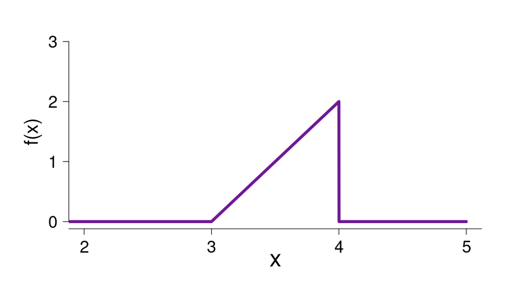

```r
x <- seq(0,5,0.001)
density <- function(x){
    f_x <- array(dim=length(x))
    for(i in 1:length(x)){
        if((3<=x[i])&(x[i]<=4)){
            f_x[i] <- 2*x[i]-6
        }
        else{
            f_x[i] <- 0
        }
    }
    return(f_x)
}
f_x <- density(x)

par(cex.axis=1.75,mar=c(5,6,3,3))
options(repr.plot.width = 9, repr.plot.height = 5)
col_dens <- '#6f1996'
plot(NULL,xlim=c(2,5),ylim=c(0,3),axes=F,ann=F)
axis(1,padj=0.25,at=1:10)
axis(2,at=0:3,las=1)
mtext('x',1,cex=2.5,line=2.5)
mtext('f(x)',2,cex=2,line=2.5)
lines(x,f_x,lwd=5,col=col_dens)
```

Podemos usar la función de densidad para calcular qué tan probable es que la variable $x$ ocurra en cierto intervalo (de su dominio). El primer paso para ello es calcular la *integral indefinida* de la función de densidad:

$$\begin{align} \int f(x)\ dx&=\int2x-6\ dx\\ &=x^2-6x+C, \end{align}$$

en donde el término $+C$ es parte del resultado de la integración. La integral indefinida describe cómo se acumula el *área bajo la curva* a medida que $x$ "avanza" (dentro de su dominio). Por lo tanto, para calcular el área bajo la curva de densidad (y de cualquier otra función) entre un par de valores $[a,b]$ evaluamos la integral indefinida en $b$ (el límite superior del intervalo) y al resultado sustraemos la misma integral indefinida pero evaluada en $a$ (el límite inferior):

$$ \mathrm{área\ bajo\ \textit{f(x)}\ entre\ \textit{a}\ y\ \textit{b}}=\int_{a}^{b}f(x)\ dx=\left.\int f(x)\ dx\right|_{b}-\left.\int f(x)\ dx\right|_{a}, $$

en donde el símbolo $|_{b}$ representa y se lee "evaluada en $b$".

En el contexto de Teoría de Probabilidad el área bajo una curva de densidad en cierto intervalo representa la probabilidad de que la variable aleatoria correspondiente tome un valor dentro de dicho intervalo. Por ejemplo, la probabilidad de que la variable $x$ tome un valor entre $3.25$ y $3.75$ se computa como:

$$\begin{align} P(3.25\leq x\leq 3.75)&=\int_{3.25}^{3.75}2x-6\ dx\\\\ &=\left.(x^2-6x)\right|_{3.75}-\left.(x^2-6x)\right|_{3.25}\\\\ &=\left(3.75^2-6(3.75)\right)-\left(3.25^2-6(3.25)\right)\\\\ &=(-8.4375)-(-8.9375)\\\\ &=0.5, \end{align}$$

que gráficamente se ve:

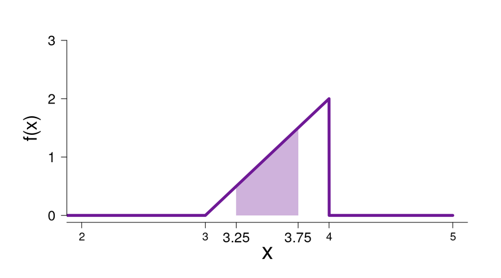

```r
par(cex.axis=1.5,mar=c(5,6,3,3))
options(repr.plot.width = 9, repr.plot.height = 5)
col_dens <- '#6f1996'
plot(NULL,xlim=c(2,5),ylim=c(0,3),axes=F,ann=F)
interval <- c(3.25,3.75)
polygon(x=c(interval,interval[2:1]),
        y=c(rep(0,2),density(interval[2:1])),
       border=NA,col=paste(col_dens,'55',sep=''))
lines(x,f_x,lwd=5,col=col_dens)
axis(1,at=1:10,cex.axis=1.2,padj=-.25)
axis(1,at=interval,lwd.ticks = 1,lwd=0,font=1)
axis(2,at=0:3,las=1)
mtext('x',1,cex=2.5,line=2.5)
mtext('f(x)',2,cex=2,line=2.5)
```

De manera análoga a la restricción principal de una distribución sobre variables discretas, en el caso de variables continuas el área total bajo la curva de densidad (en el dominio de la variable) debe agregar $1$, lo cual nuevamente representa que dicha curva da cuenta de la incertidumbre sobre todas las posibilidades de la variable:

$$\int\limits_x f(x)\ dx=1$$

En nuestro ejemplo:

$$\begin{align} \int\limits_x f(x)\ dx&=\int_{3}^{4} 2x-6\ dx\\ &=\left.(x^2-6x)\right|_{4}-\left.(x^2-6x)\right|_{3}\\\\ &=\left(4^2-6(4)\right)-\left(3^2-6(3)\right)\\\\ &=(16-24)-(9-18)\\\\ &=1, \end{align}$$

es decir, el área total bajo este *triángulo* de densidad es $1$:

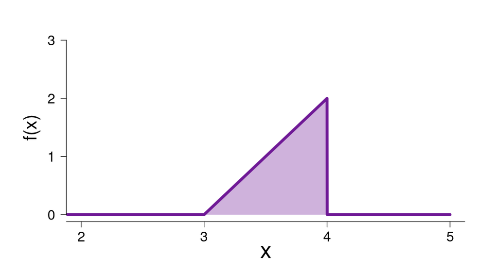

```r
par(cex.axis=1.5,mar=c(5,6,3,3))
options(repr.plot.width = 9, repr.plot.height = 5)
col_dens <- '#6f1996'
plot(NULL,xlim=c(2,5),ylim=c(0,3),axes=F,ann=F)
interval <- c(3,4)
polygon(x=c(interval,interval[2:1]),
        y=c(rep(0,2),density(interval[2:1])),
       border=NA,col=paste(col_dens,'55',sep=''))
lines(x,f_x,lwd=5,col=col_dens)
axis(1,at=1:10)
axis(2,at=0:3,las=1)
mtext('x',1,cex=2.5,line=2.5)
mtext('f(x)',2,cex=2,line=2.5)
```

En este ejemplo particular podemos comprobar el resultado de la integración visual y geométricamente: el área bajo la curva de densidad equivale al área total de un triángulo que tiene $base=1$ y $altura=2$. Aparte, este ejemplo también ilustra una de las diferencias más importantes entre una **densidad** de probabilidad (variables continuas) y una **masa** de probabilidad (variables discretas): mientras que todos los valores de una **función de masa** siempre se encuentran entre $\{0,1\}$, los valores de una **función de densidad** pueden exceder $1$ en algunas regiones de la variable, como ocurre en este ejemplo en la región $x\in(3.5,4]$. En este sentido, las funciones de **densidad** no representan directamente la probabilidad $P(X=x)$, sino que son *funciones que al integrarse en cierto intervalo devuelven la probabilidad de que $X$ ocurra en ese intervalo*, aunque a fin de cuentas la altura relativa de la función de densidad indirectamente dice qué regiones de la variable son más probables que otras.

#### Referencias recomendadas

- Strogatz, S. (2019). *Infinite Powers. How calculus reveals the secrets of the universe.* Eamon Dolan.
- *Essence of Calculus* por Grant Sanderson: https://www.youtube.com/playlist?list=PLZHQObOWTQDMsr9K-rj53DwVRMYO3t5Yr (¡todo el canal *3Blue1Brown* tiene contenido muy interesante!)

Aunque algunas herramientas formales cambian entre variables discretas y continuas, la idea siempre es la misma: las variables aleatorias representan espacios de posibilidades, mientras que las distribuciones (en forma de masa o de densidad) representan la plausibilidad relativa de dichas posibilidades.

### Distribución Uniforme

*Asigna la misma densidad relativa a todos los valores de la variable aleatoria en cierto intervalo.*

$$\begin{align} \mathrm{\textbf{Variable Aleatoria}}\\ x\in[a,b]\\ &\textrm{Variable continua definida en}\\ &\textrm{el intervalo [$a$,$b$]}\\\\ \mathrm{\textbf{Parámetros}}\\ a,b\in\mathbb{R}: -\infty<a<b<\infty\\ &\textrm{Límites inferior ($a$) y}\\ &\textrm{superior ($b$) de la variable.}\\\\ \mathrm{\textbf{Función de Densidad}}\\ \mathrm{\textbf{de Probabilidad (PDF)}}\\ &f(x)=\frac{1}{b-a}\mathbb{1}_{[a,b]}^{(x)}\\\\ \mathrm{\textbf{Notación Compacta}}\\ &x\sim Uniform(a,b) \end{align}$$

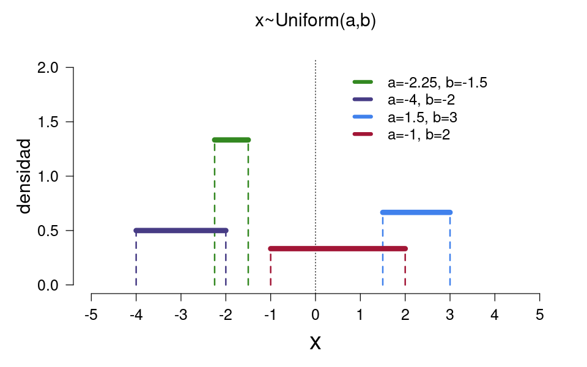

```r
uniform <- function(a,b){
    x <- seq(a,b,length.out = 50)
    pdf <- rep(1/(b-a),length(x))
    return(list(x=x,pdf=pdf))
}

inf <- c(-2.25,-4,1.5,-1)
sup <- c(-1.50,-2,3,2)
colors <- c("#338821", "#473c85", "#4081ec", "#a21636")
options(repr.plot.width = 8, repr.plot.height = 5)
par(cex.axis=1.25,mar=c(5,5,4,2))
plot(NULL,xlim=c(-5,5),ylim=c(0,2),axes=F,ann=F)
abline(v=0,lty='dotted')
labels <- NULL
for(j in 1:length(inf)){
    dist <- uniform(inf[j],sup[j])
    segments(x0=c(inf[j],sup[j]),x1=c(inf[j],sup[j]),
            y0=rep(0,2),y1=max(dist$pdf),lty='dashed',col=colors[j],lwd=2)
    lines(dist$x,dist$pdf,lwd=7,col=colors[j])
    labels <- append(labels,paste('a=',round(inf[j],2),', b=',sup[j],sep=''))
}
legend(0.5,2,xjust=0,yjust=1,legend=labels,
      col=colors,lwd=5,seg.len=1,y.intersp=1.5,box.lty='blank',cex=1.2)
mtext('x',1,line=3,cex=2)
mtext('densidad',2,line=2.75,cex=1.5)
mtext('x~Uniform(a,b)',3,line=2,cex=1.5)
axis(1,at=-5:5)
axis(2,las=1)
```

### Distribución Exponencial

*Densidad asimétrica para variables continuas positivas.*

$$\begin{align} \mathrm{\textbf{Variable Aleatoria}}\\ x\in[0,\infty)\\ &\textrm{Variable continua definida en}\\ &\textrm{los reales positivos, i.e., $x\in\mathbb{R}^+$,}\\ &\textrm{i.e., $x\geq0$.}\\\\ \mathrm{\textbf{Parámetros}}\\ \lambda>0\\ &\textrm{"Tasa", o "escala inversa".}\\\\ \mathrm{\textbf{Función de Densidad}}\\ \mathrm{\textbf{de Probabilidad (PDF)}}\\ &f(x)=\lambda e^{-\lambda x}\\\\ \mathrm{\textbf{Notación Compacta}}\\ &x\sim Exponential(\lambda)\\\\ \textrm{Nota sobre la constante}\\ &e\approx2.71828\dots \end{align}$$

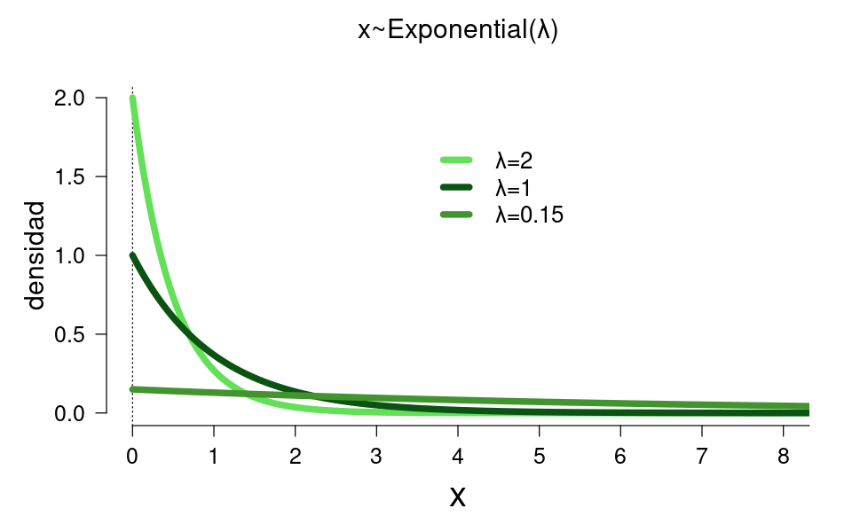

```r
exponential <- function(lambda){
    x <- seq(0,50,0.01) # Goes to infinity, though
    pdf <- lambda*exp(-lambda*x)
    return(list(x=x,pdf=pdf))
}

lmbd <- c(2,1,0.15)
colors <- c('#64e058','#0b5313','#42952e')
options(repr.plot.width = 8, repr.plot.height = 5)
par(cex.axis=1.25,mar=c(5,5,4,2))
plot(NULL,xlim=c(0,8),ylim=c(0,2),axes=F,ann=F)
abline(v=0,lty='dotted')
labels <- NULL
for(j in 1:length(lmbd)){
    dist <- exponential(lmbd[j])
    lines(dist$x,dist$pdf,lwd=6,col=colors[j])
}
legend(3.5,1.75,xjust=0,yjust=1,legend=paste('\u03bb=',lmbd,sep=''),
      col=colors,lwd=6,seg.len=1,y.intersp=1.5,box.lty='blank',cex=1.3)
mtext('x',1,line=3,cex=2)
mtext('densidad',2,line=2.75,cex=1.5)
mtext('x~Exponential(\u03bb)',3,line=2,cex=1.5)
axis(1,at=0:10)
axis(2,las=1)
```

### Distribución Gamma

*Densidad asimétrica, pero con diferentes formas, para variables continuas positivas.*

$$\begin{align} \mathrm{\textbf{Variable Aleatoria}}\\ x\in[0,\infty)\\ &\textrm{Variable continua definida en}\\ &\textrm{los reales positivos.}\\\\ \mathrm{\textbf{Parámetros}}\\ r>0\\ &\textrm{"Forma".}\\ \lambda>0\\ &\textrm{"Tasa".}\\\\ \mathrm{\textbf{Función de Densidad}}\\ \mathrm{\textbf{de Probabilidad (PDF)}}\\ &f(x)=\frac{\lambda^r x^{r-1} e^{-\lambda x}}{\Gamma{(r)}}\\\\ \mathrm{\textbf{Notación Compacta}}\\ &x\sim Gamma(r,\lambda)\\\\ \textrm{Nota sobre la constante}\\ &e\approx2.71828\dots\\\\ \textrm{Nota sobre la función Gamma}\\ &\Gamma(z)\\ &\textrm{Se conoce como "función Gamma",}\\ &\textrm{con aplicaciones en muchas ramas}\\ &\textrm{de las matemáticas. Para un entero}\\ &\textrm{positivo $n$, se define como:}\\\\ &\Gamma(n)=(n-1)!\\\\ &\textrm{Aunque en general está definida (de}\\ &\textrm{otra manera) para cualquier número}\\ &\textrm{complejo con parte real positiva.} \end{align}$$

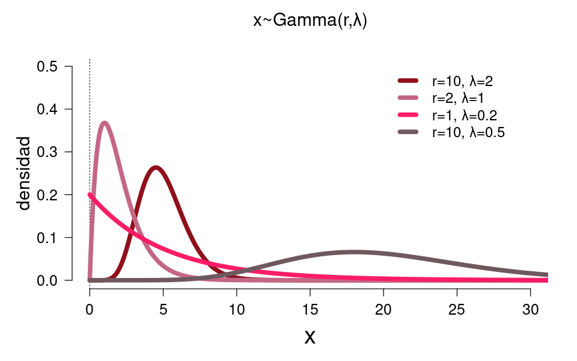

```r
dgamma <- function(r,lambda){
    x <- seq(0,50,0.01) # Goes to infinity, though
    pdf <- lambda^r*x^(r-1)*exp(-lambda*x)/gamma(r) # Note the homonymous function!
    return(list(x=x,pdf=pdf))
}

r <- c(10,2,1,10)
lmbd <- c(2,1,.2,.5)
colors <- c("#8f0f1b", "#c36785", "#fe1d66", "#6e595f")
options(repr.plot.width = 8, repr.plot.height = 5)
par(cex.axis=1.25,mar=c(5,5,4,2))
plot(NULL,xlim=c(0,30),ylim=c(0,0.5),axes=F,ann=F)
abline(v=0,lty='dotted')
labels <- NULL
for(j in 1:length(lmbd)){
    dist <- dgamma(r[j],lmbd[j])
    lines(dist$x,dist$pdf,lwd=6,col=colors[j])
    labels <- append(labels,paste('r=',r[j],', \u03bb=',lmbd[j],sep=''))
}
legend(20,.5,xjust=0,yjust=1,legend=labels,
      col=colors,lwd=6,seg.len=1,y.intersp=1.5,box.lty='blank',cex=1.2)
mtext('x',1,line=3,cex=2)
mtext('densidad',2,line=2.75,cex=1.5)
mtext('x~Gamma(r,\u03bb)',3,line=2,cex=1.5)
axis(1)
axis(2,las=1)
```

### Distribución Normal

*La campana clásica.*

$$\begin{align} \mathrm{\textbf{Variable Aleatoria}}\\ x\in\mathbb{R}\\ &\textrm{Variable continua definida en}\\ &\textrm{todos los $reales$, i.e., $x\in(-\infty,\infty)$.}\\\\ \mathrm{\textbf{Parámetros}}\\ \mu\in\mathbb{R}\\ &\textrm{Posición/ubicación de la curva}\\ &\textrm{en la escala de $x$.}\\ \sigma>0\\ &\textrm{Dispersión respecto de $\mu$.}\\\\ \mathrm{\textbf{Función de Densidad}}\\ \mathrm{\textbf{de Probabilidad (PDF)}}\\ &f(x)=\frac{1}{\sigma\sqrt{2\pi}}e^{-\frac{1}{2}\left(\frac{x-\mu}{\sigma}\right)^2}\\\\ \mathrm{\textbf{Notación Compacta}}\\ &x\sim Normal(\mu,\sigma)\\ &x\sim Gaussian(\mu,\sigma)\\ &x\sim Normal(\mu,\sigma^2)\\ &x\sim Gaussian(\mu,\sigma^2)\\ &x\sim Normal\left(\mu,\frac{1}{\sigma^2}\right)\\ &x\sim Gaussian\left(\mu,\frac{1}{\sigma^2}\right)\\ \textrm{Nota sobre las constantes}\\ &\pi\approx3.14159\dots\\ &e\approx2.71828\dots \end{align}$$

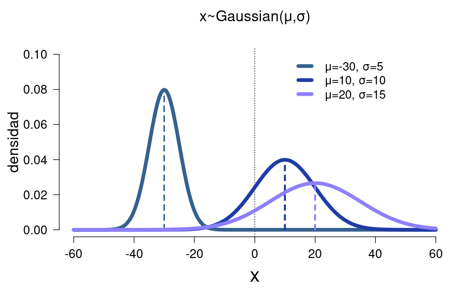

```r
gaussian <- function(mu,sigma){
    x <- seq(-60,60,0.01) # Goes to infinity both ways, though
    pdf <- (1/(sigma*sqrt(2*pi)))*exp((-1/2)*((x-mu)/sigma)^2)
    return(list(x=x,pdf=pdf))
}

mu <- c(-30,10,20)
sigma <- c(5,10,15)
colors <- c('#579ba1','#0a4f4e','#47f0a3')
colors <- c("#35618f", "#1f3ca6", "#8e80fb")
options(repr.plot.width = 8, repr.plot.height = 5)
par(cex.axis=1.25,mar=c(5,5,4,2))
plot(NULL,xlim=c(-60,60),ylim=c(0,0.1),axes=F,ann=F)
abline(v=0,lty='dotted')
labels <- NULL
for(j in 1:length(mu)){
    dist <- gaussian(mu[j],sigma[j])
    segments(x0=mu[j],x1=mu[j],y0=0,y1=gaussian(mu[j],sigma[j])$pdf,lty='dashed',col=colors[j],lwd=2)
    lines(dist$x,dist$pdf,lwd=6,col=colors[j])
    labels <- append(labels,paste('\u03bc=',mu[j],', \u03c3=',sigma[j],sep=''))
}
legend(10,.1,xjust=0,yjust=1,legend=labels,
      col=colors,lwd=6,seg.len=1,y.intersp=1.5,box.lty='blank',cex=1.2)
mtext('x',1,line=3,cex=2)
mtext('densidad',2,line=3.25,cex=1.5)
mtext('x~Gaussian(\u03bc,\u03c3)',3,line=2,cex=1.5)
axis(1)
axis(2,las=1)
```

### Distribución Beta

*Para variables continuas entre $0$ y $1$.*

$$\begin{align} \mathrm{\textbf{Variable Aleatoria}}\\ \theta\in[0,1]\\ &\textrm{Variable continua definida}\\ &\textrm{entre $0$ y $1$.}\\\\ \mathrm{\textbf{Parámetros}}\\ \alpha>0\\ \beta>0\\ &\textrm{Parámetros de "forma".}\\\\ \mathrm{\textbf{Función de Densidad}}\\ \mathrm{\textbf{de Probabilidad (PDF)}}\\ &f(\theta)=\frac{\theta^{\alpha-1}(1-\theta)^{\beta-1}}{\textrm{B}(\alpha,\beta)}\mathbb{1}_{[0,1]}^{(\theta)}\\\\ \mathrm{\textbf{Notación Compacta}}\\ &\theta\sim Beta(\alpha,\beta)\\\\ \textrm{Nota sobre la función Beta}\\ &\textrm{B}(\alpha,\beta)=\frac{\Gamma(\alpha)\Gamma(\beta)}{\Gamma(\alpha+\beta)}\\ &\textrm{Se conoce como "función Beta"}\\ &\textrm{y está definida en términos de}\\ &\textrm{la función Gamma.} \end{align}$$

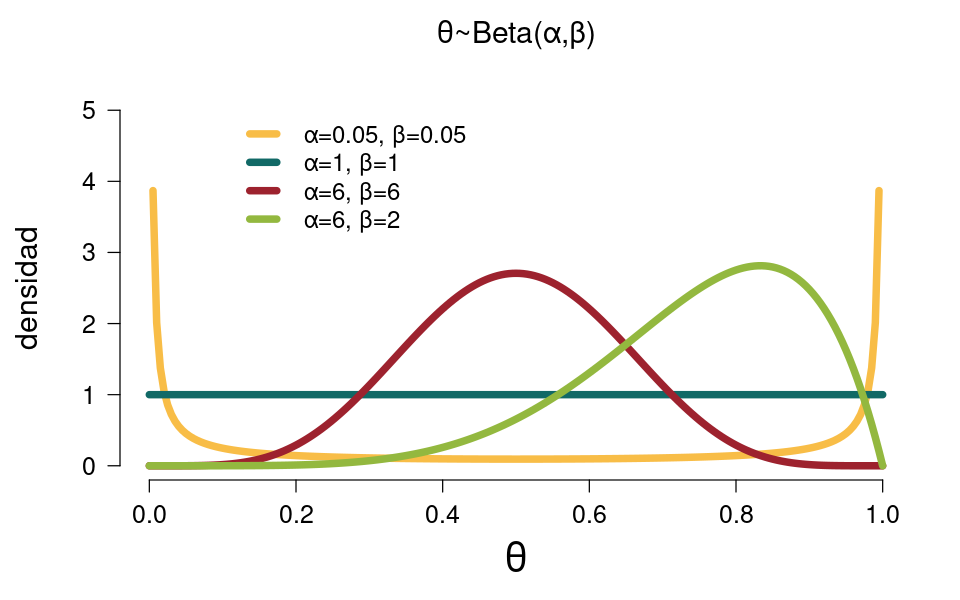

```r
dbeta <- function(alpha,beta){
    th <- seq(0,1,0.005)
    pdf <- (th^(alpha-1)*(1-th)^(beta-1))/(beta(alpha,beta))
    return(list(th=th,pdf=pdf))
}

alpha <- c(0.05,1,6,6)
beta <- c(0.05,1,6,2)
colors <- c("#f8bd47", "#116966", "#9d222e", "#93b83f")
options(repr.plot.width = 8, repr.plot.height = 5)
par(cex.axis=1.25,mar=c(5,5,4,2))
plot(NULL,xlim=c(0,1),ylim=c(0,5),axes=F,ann=F)
labels <- NULL
for(j in 1:length(alpha)){
    dist <- dbeta(alpha[j],beta[j])
    lines(dist$th,dist$pdf,lwd=6,col=colors[j])
    labels <- append(labels,paste('\u03b1=',alpha[j],', \u03b2=',beta[j],sep=''))
}
legend(.1,5,xjust=0,yjust=1,legend=labels,
      col=colors,lwd=6,seg.len=1,y.intersp=1.5,box.lty='blank',cex=1.2,bg='#00000000')
mtext('\u03b8',1,line=3,cex=2)
mtext('densidad',2,line=3.25,cex=1.5)
mtext('\u03b8~Beta(\u03b1,\u03b2)',3,line=2,cex=1.5)
axis(1)
axis(2,las=1)
```

### Inferencia sobre no-observables continuos

Si bien las funciones de densidad se comportan ligeramente diferente a las funciones de masa, los principios de inferencia funcionan igual para ambos tipos de variable. Para ejemplificar consideren el siguiente problema sobre una variable no-observable continua, que es similar al problema de inferencia sobre un no-observable discreto que resolvieron como tarea.

Cierta compañía inagura nuevas fábricas en un país extranjero para producir sus productos localmente. En particular, buscan $r=5$ personas para operar cierta máquina. La organización desconoce la probabilidad de éxito por candidato, pero su experiencia previa sugiere que esta probabilidad es baja, o bien, que los candidatos aptos son raros. Sin embargo, la compañía únicamente se ve en la necesidad de entrevistar a $7$ aplicantes en el país extranjero, porque encuentra a sus candidatos requeridos casi de inmediato, después de observar únicamente $x=2$ fracasos antes de los $r=5$ éxitos. *¿Qué debería creer la compañía sobre la probabilidad de éxito por participante después de observar esta evidencia?*

Suponiendo independencia y distribución idéntica entre participantes, es razonable utilizar el siguiente modelo:

$$\begin{align} \theta&\sim Beta(1,2)\\ r&\leftarrow 5\\ x&\leftarrow 2\\ x|\theta,r&\sim NegBinomial(\theta,r)\\ \end{align}$$

En palabras, esta vez conocemos el número de éxitos objetivo y también medimos el número de fracasos. No conocemos la probabilidad de éxito, pero nuevamente conocemos la relación entre la variable observada y la no-observable, que en este ejemplo se trata de una variable no-observable continua:

[figure not shown]

### Solución Analítica

Comenzaremos examinando la incertidumbre inicial sobre $\theta$ (¡que puede interprerse como un espacio de hipótesis infinito!).

$$\begin{align} \theta\sim Beta(1,2)\Rightarrow p(\theta)&=\frac{\theta^{1-1}(1-\theta)^{2-1}}{\textrm{B}(1,2)}\\\\ &=\frac{1-\theta}{\frac{\Gamma(1)\Gamma(2)}{\Gamma(2+1)}}\\\\ &=\frac{1-\theta}{\frac{(0!)(1!)}{2!}}\\\\ &=2(1-\theta)\\\\ &=2-2\theta \end{align}$$

Graficando esta incertidumbre inicial:

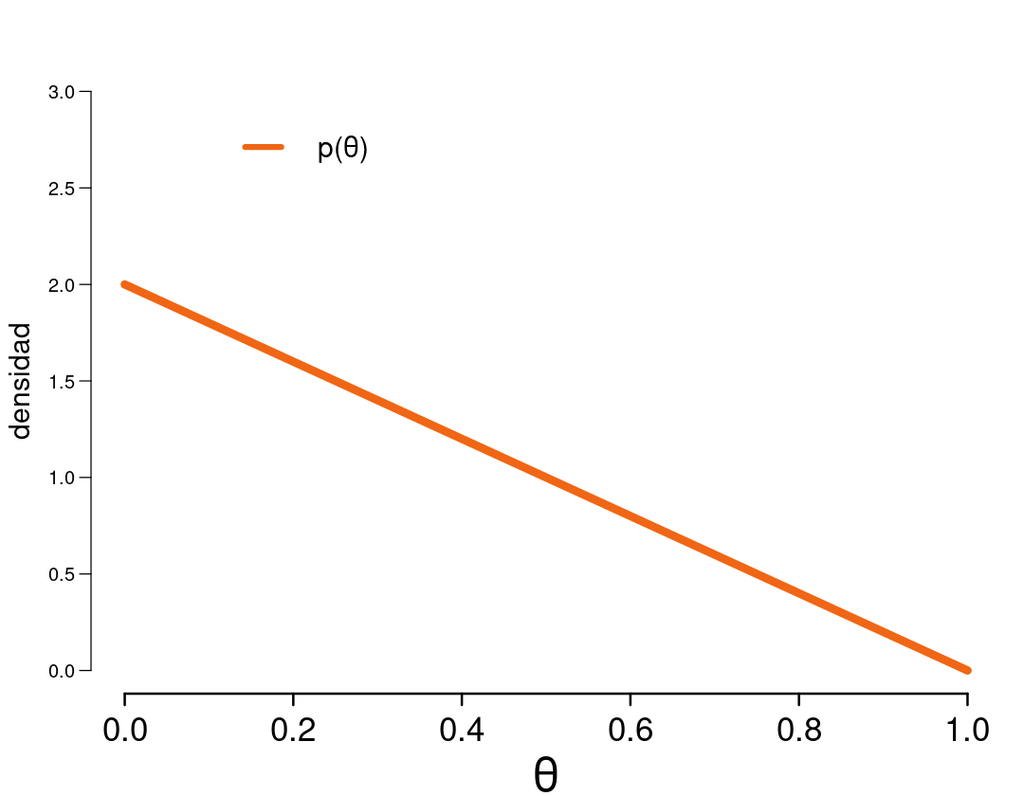

```r
theta <- seq(0,1,0.01)
p_theta <- 2-2*theta

col_prior <- '#f06614'
col_like <- '#208eb7'
col_post <- '#ec102f'
options(repr.plot.width = 9, repr.plot.height = 7)
par(mar=c(4.5,4,3,1))
plot(NULL,xlim=c(0,1),ylim=c(0,3),axes=F,ann=F)
lines(theta,p_theta,lwd=7,col=col_prior)
legend(0.1,2.9,xjust=0,yjust=1,legend=c('p(\u03b8)'),
      lwd=5,col=c(col_prior),
      seg.len=1,y.intersp=1,box.lty='blank',cex=1.5,bg='#00000000')
axis(1,cex.axis=1.75,lwd=2,padj=.25)
axis(2,las=1,hadj=.75)
mtext('densidad',2,line=2.5,cex=1.5)
mtext('\u03b8',1,line=3.5,cex=2.5)
```

Es decir, la organización llegó al país nuevo suponiendo que la probabilidad de éxito por participante, $\theta$, era baja, en el sentido de que la mayor densidad a priori se concentra en valores pequeños de $\theta$ (digamos, menores que $\frac{1}{2}$), mientras que la densidad a priori sobre valores altos de $\theta$ (diagamos $\theta>\frac{1}{2}$) es baja.

A continuación necesitamos la función de verosimilitud $P(x=2|\theta)$. Nuevamente emplearemos el modelo Binomial Negativo, pero a diferencia del ejercicio anterior en el que no conocíamos el número $r$ de éxitos objetivo, en este ejemplo sí conocemos $r=5$ pero desconocemos $\theta$. Por lo tanto, la verosimilitud en este ejemplo es función de $\theta$:

$$\begin{align}P(x=2|\theta)&={2+5-1\choose 2}\theta^5(1-\theta)^2\\\\ &={6\choose 2}\theta^5(1-\theta)^2\\\\ &=\frac{6!}{2!(6-2)!}\theta^5(1-2\theta+\theta^2)\\\\ &=15\theta^5(1-2\theta+\theta^2)\\\\ &=15\theta^5-30\theta^6+15\theta^7, \end{align}$$

función que favorece valores altos de $\theta$, como puede apreciarse visualmente:

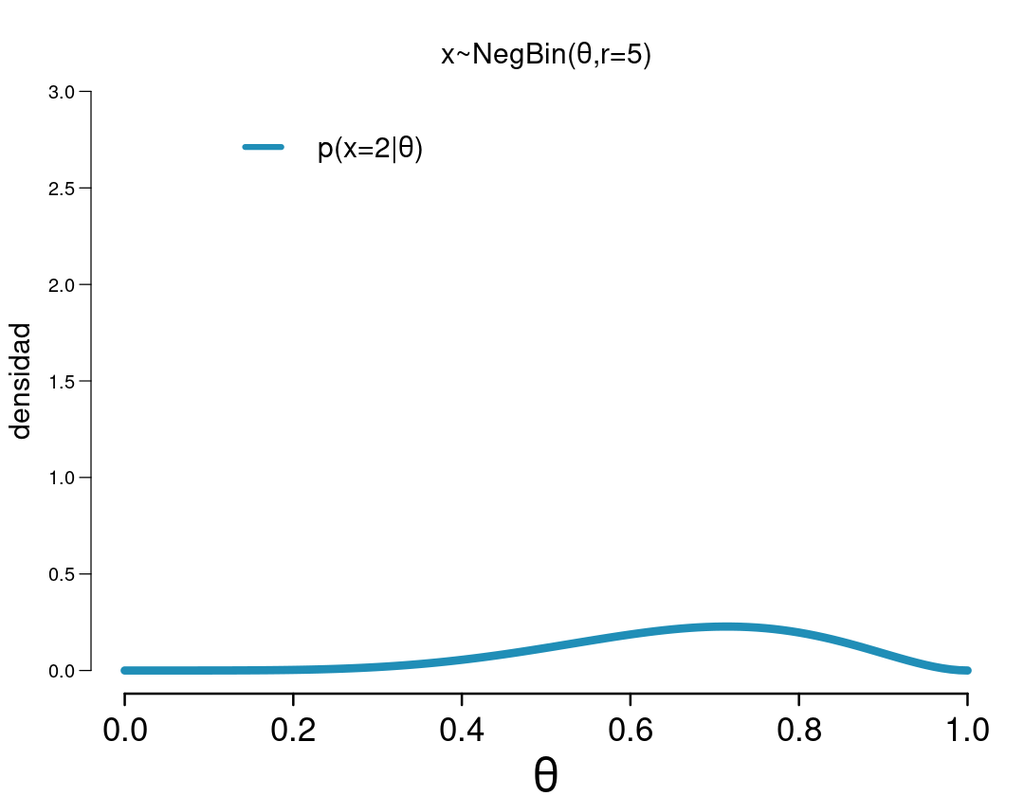

```r
theta <- seq(0,1,0.01)
p_theta <- 2-2*theta
p_x_D_theta <- 15*theta^5-30*theta^6+15*theta^7

col_prior <- '#f06614'
col_like <- '#208eb7'
col_post <- '#ec102f'
options(repr.plot.width = 9, repr.plot.height = 7)
par(mar=c(4.5,4,3,1))
plot(NULL,xlim=c(0,1),ylim=c(0,3),axes=F,ann=F)
lines(theta,p_x_D_theta,lwd=7,col=col_like)
legend(0.1,2.9,xjust=0,yjust=1,legend=c('p(x=2|\u03b8)'),
      lwd=5,col=c(col_like),
      seg.len=1,y.intersp=1,box.lty='blank',cex=1.5,bg='#00000000')
axis(1,cex.axis=1.75,lwd=2,padj=.25)
axis(2,las=1,hadj=.75)
mtext('densidad',2,line=2.5,cex=1.5)
mtext('\u03b8',1,line=3.5,cex=2.5)
mtext('x~NegBin(\u03b8,r=5)',3,line=0,cex=1.5)
```

De la misma manera que con variables discretas, la Regla de Bayes especifica cómo actualizar la incertidumbre sobre $\theta$ a partir de la densidad a priori y de la verosimilitud de la evidencia bajo todos sus posibles valores:

$$P(\theta|x=2)=\frac{P(x=2|\theta)P(\theta)}{\int_\Theta P(x=2|\theta)P(\theta)}$$

Calculando la conjunta $P(x=2,\theta)$:

$$\begin{align} P(x=2,\theta)&=P(x=2|\theta)P(\theta)\\\\ &=(15\theta^5-30\theta^6+15\theta^7)(2-2\theta)\\\\ &=-30\theta^8+90\theta^7-90\theta^6+30\theta^5, \end{align}$$

que podemos integrar a través de todos los valores posibles de $\theta$ para conseguir la probabilidad marginal $P(x=2)$:

$$\begin{align} P(x=2)&=\int_\Theta P(x=2|\theta)P(\theta)\\\\ &=\int_{0}^{1} -30\theta^8+90\theta^7-90\theta^6+30\theta^5 d\theta\\\\ &=\left.\left(-\frac{30}{9}\theta^9+\frac{90}{8}\theta^8-\frac{90}{7}\theta^7+\frac{30}{6}\theta^6\right)\right|_1-\left(\left.-\frac{30}{9}\theta^9+\frac{90}{8}\theta^8-\frac{90}{7}\theta^7+\frac{30}{6}\theta^6\right)\right|_0\\\\ &=-\frac{10}{3}+\frac{90}{8}-\frac{90}{7}+\frac{5}{1}\\\\ &=\frac{10}{168} \end{align}$$

Finalmente, actualizando la incertidumbre sobre $\theta$:

$$\begin{align} P(\theta|x=2)&=\frac{P(x=2|\theta)P(\theta)}{\int_\Theta P(x=2|\theta)P(\theta)}\\\\ &=\frac{-30\theta^8+90\theta^7-90\theta^6+30\theta^5}{\frac{10}{168}}\\\\ &=\frac{(168)(-30\theta^8+90\theta^7-90\theta^6+30\theta^5)}{10}\\\\ &=-504\theta^8+1512\theta^7-1512\theta^6+504\theta^5, \end{align}$$

que gráficamente luce como una mezcla entre las creencias a priori y la función de verosimilitud:

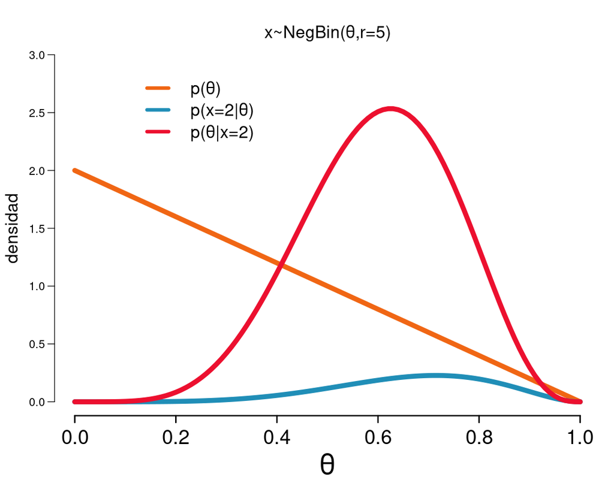

```r
theta <- seq(0,1,0.01)
p_theta <- 2-2*theta
p_x_D_theta <- 15*theta^5-30*theta^6+15*theta^7
p_theta_D_x <- -504*theta^8+1512*theta^7-1512*theta^6+504*theta^5

col_prior <- '#f06614'
col_like <- '#208eb7'
col_post <- '#ec102f'
options(repr.plot.width = 9, repr.plot.height = 7)
par(mar=c(4.5,4,3,1))
plot(NULL,xlim=c(0,1),ylim=c(0,3),axes=F,ann=F)
lines(theta,p_theta,lwd=7,col=col_prior)
lines(theta,p_x_D_theta,lwd=7,col=col_like)
lines(theta,p_theta_D_x,lwd=7,col=col_post)
legend(0.1,2.9,xjust=0,yjust=1,legend=c('p(\u03b8)','p(x=2|\u03b8)','p(\u3b8|x=2)'),
      lwd=5,col=c(col_prior,col_like,col_post),
      seg.len=1,y.intersp=1,box.lty='blank',cex=1.5,bg='#00000000')
axis(1,cex.axis=1.75,lwd=2,padj=.25)
axis(2,las=1,hadj=.75)
mtext('densidad',2,line=2.5,cex=1.5)
mtext('\u03b8',1,line=3.5,cex=2.5)
mtext('x~NegBin(\u03b8,r=5)',3,line=0,cex=1.5)
```

En palabras, después de observar $x=2$ fracasos antes de llegar a $r=5$ éxitos, la organización debería concluir que la probabilidad de éxito por participante en el país nuevo es alta, porque la densidad posterior sobre $\theta$ se concentra en valores mayores que $\frac{1}{2}$; sin embargo, la incertidumbre final también refleja las creencias a priori, en el sentido de que hay densidad posterior considerable entre, digamos $\theta=0.3$ y $\theta=0.5$.

Al margen de los detalles de esta distribución posterior particular, en general la densidad posterior sobre una variable no-observable continua nuevamente representa el estado de conocimiento actualizado sobre esa variable, partiendo de cierto conjunto de creencias iniciales y a la luz de cierta evidencia.

#### Nota sobre otra presentación de Bayes

Aprovecharemos el ejemplo anterior para explicar otra manera común de presentar la Regla de Bayes. Para ello agregaremos el producto $P(x=2|\theta)P(\theta)$ a la gráfica anterior:

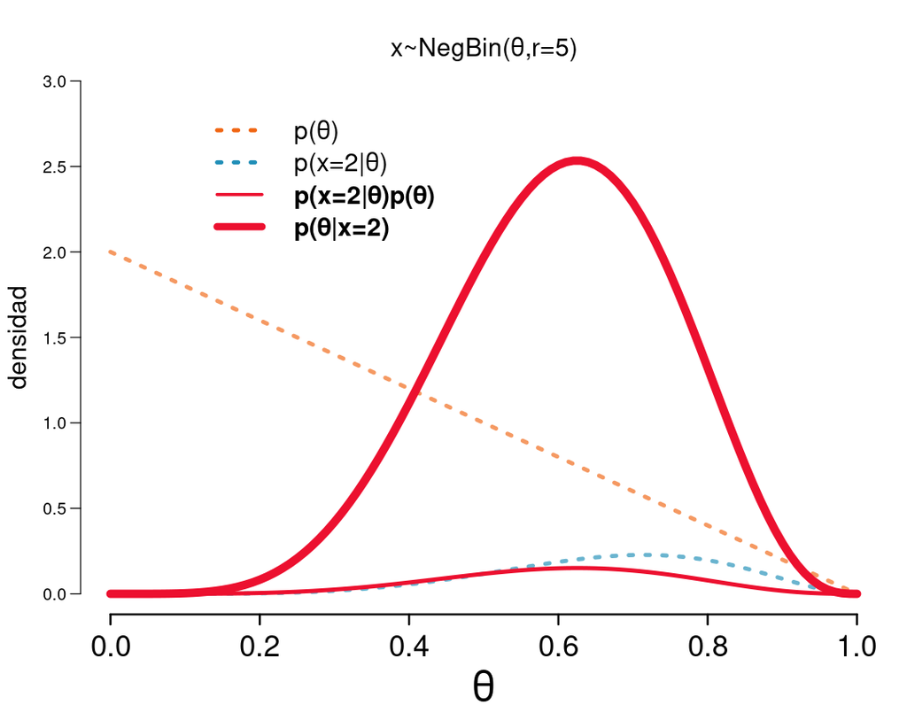

```r
theta <- seq(0,1,0.01)
p_theta <- 2-2*theta
p_x_D_theta <- 15*theta^5-30*theta^6+15*theta^7
p_x_theta <- -30*theta^8+90*theta^7-90*theta^6+30*theta^5
p_theta_D_x <- -504*theta^8+1512*theta^7-1512*theta^6+504*theta^5

col_prior <- '#f06614'
col_like <- '#208eb7'
col_post <- '#ec102f'
options(repr.plot.width = 9, repr.plot.height = 7)
par(mar=c(4.5,4,3,1))
plot(NULL,xlim=c(0,1),ylim=c(0,3),axes=F,ann=F)
lines(theta,p_theta,lwd=4,col=paste(col_prior,'aa',sep=''),lty='dotted')
lines(theta,p_x_D_theta,lwd=4,col=paste(col_like,'aa',sep=''),lty='dotted')
lines(theta,p_x_theta,lwd=4,col=col_post)
lines(theta,p_theta_D_x,lwd=8,col=col_post)
legend(0.1,2.9,xjust=0,yjust=1,legend=c('p(\u03b8)','p(x=2|\u03b8)','p(x=2|\u3b8)p(\u03b8)','p(\u3b8|x=2)'),
      lwd=c(4,4,3,7),lty=c('dotted','dotted','solid','solid'),col=c(col_prior,col_like,col_post,col_post),
      seg.len=1.4,y.intersp=1,box.lty='blank',cex=1.5,bg='#00000000',text.font=c(1,1,2,2))
axis(1,cex.axis=1.75,lwd=2,padj=.25)
axis(2,las=1,hadj=.75)
mtext('densidad',2,line=2.5,cex=1.5)
mtext('\u03b8',1,line=3.5,cex=2.5)
mtext('x~NegBin(\u03b8,r=5)',3,line=0,cex=1.5)
```

Al comparar la posterior $P(\theta|x=2)$ con la conjunta $P(x=2|\theta)P(\theta)$ resulta evidente que ambas tienen la misma forma respecto de $\theta$, aunque difieren en altura. De hecho, la diferencia entre la altura de la posterior y la altura de la conjunta se origina después de reescalar la conjunta, al dividirla entre su propia suma ($\frac{10}{168}$ en el ejemplo anterior). En otras palabras, la posterior sobre la no-observable *es* la conjunta entre la evidencia y la no-observable **reescalada** respecto de su propia suma, o bien, una vez que se conoce la conjunta implícitamente se conoce la posterior. Para expresar la Regla de Bayes en estos términos es común encontrar la notación:

$$P(\theta|x)\propto P(x|\theta)P(\theta),$$

en donde el símbolo $\propto$ representa "proporcional a".